# esiil-amf-mdehollander

### Mattias de Hollander, MSc

### Bioinformatician, Netherlands Institute of Ecology (NIOO-KNAW), NL

📧 m.dehollander@nioo.knaw.nl · [Github: @mdehollander](https://www.github.com/mdehollander) · https://nioo.knaw.nl/en/employees/mattias-de-hollander

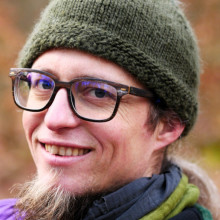

### 🧑 About Me

Bioinformatician with 10+ years of experience in data analysis,data infrastructure, and reproducible research. Passionate about making data analysis transparent, reproducible, and accessible.

### 🛠️ Skills

- R
- Python
- Bash scripting
- Snakemake
- Nextflow
- Git
- Markdown
- High Performance Computing (HPC)

### 💼 Expertise

- amplicon metagenomics
- shotgun metagenomics
- amplicon sequencing (NGS)
- taxonomic classification
- data curation & management
- pipeline development
- reproducible research

# </> Pipeline updates

- a new pipeline as update to the original LSU pipeline is in development
- it uses the nextflow nf-core/ampliseq pipeline for initial sequence processing
- Tree building and phylogenetic placement are performed by epa-ng and happa
- Original R scripts are used for clade extraction and taxonomy assignment

Source code and documentation: [mdehollander/AMF-LSU-Database-and-Pipeline2 (ampliseq branch)](https://github.com/mdehollander/AMF-LSU-Database-and-Pipeline2/tree/ampliseq/2024_AMFPipeline/2024_AMFPipeline_ASV)

**Work in progress**

This pipeline is under active development. Scripts and documentation may change as we finalize the workflow.

- Planned development: These post-ampliseq scripts are currently executed manually in sequence. A standalone Nextflow pipeline is in development that will automate these downstream scripts into a single, reproducible workflow run after ampliseq.